# Violence sexuelle par un partenaire intime

Joel KOSIANZA BELABO

2025-09-05

# 1 Preambule

## 1.1 Introduction

La violence sexuelle perpétrée par un partenaire intime constitue une violation grave des droits humains et un problème majeur de santé publique. Elle expose les femmes à des conséquences physiques, psychologiques et sociales durables, tout en reflétant les inégalités persistantes entre les sexes. Dans le cadre de cette étude, nous mesurons la proportion de femmes âgées de 15 à 49 ans, ayant déjà eu un partenaire intime, qui déclarent avoir subi des violences sexuelles de la part de leur mari ou partenaire actuel ou le plus récent.

L’analyse s’appuie sur les données de l’Enquête Démographique et de Santé (EDS) de la **Gambie**, à travers le module sur la violence domestique ([Lien DHS](https://dhsprogram.com/Data/Guide-to-DHS-Statistics/index.cfm)). L’objectif est de :

1. Décrire l’ampleur et les formes de la violence sexuelle conjugale chez les femmes gambiennes, à partir d’indicateurs comparables aux standards internationaux.
2. Suivre son évolution dans le temps et éclairer les politiques de prévention et de protection des femmes contre les violences sexuelles au sein du couple.

## 1.2 Quelques critères d’inclusion

- Toutes les femmes agées de 15 à 49 ans selectionnées et interrogées pour le module violence domestique (cfr modalité 1 sur la variable v044) qui declarent avoir déjà été mariées ou avoir déjà eu un partenaire intime.
1. Expérience au cours de la vie : Nombre de femmes répondant « oui » à l’un des actes de violence sexuelle suivants, commis par leur mari/partenaire : Forcée physiquement à avoir des rapports sexuels sans le vouloir OU Forcée physiquement à accomplir d’autres actes sexuels non désirés OU Forcée sous la menace ou par tout autre moyen à accomplir des actes sexuels non désirés
2. Expérience au cours des 12 derniers mois : Nombre de femmes déclarant que chacun de ces actes s’est produit « souvent » ou « parfois » :

# 2 Résultat

## 2.1 Prévalence

**Proportion de femmes (15–49 ans) ayant déjà eu un partenaire intime et déclarant avoir subi une violence sexuelle** : En Gambie, seulement **6.14 %**, soit **120** sur **1953** femmes ayant répondu au module de violence sexuelle — ont déclaré avoir subi au moins une forme de violence sexuelle (actes forcés, contrainte, rapport sexuel imposé). Ce faible taux pourrait refléter une application des politiques publiques efficaces, des campagnes de sensibilisation et une évolution des normes sociales.

Mais egalement une indication d’une plus **grande égalité de genre** ou une **tolérance sociale** plus faible envers la violence.

Toute forme de violence

| Reponses | Effectif | Pourcentage |
| --- | --- | --- |
| Non | 1,833 | 93.9% |
| Oui | 120 | 6.1% |
| Total | 1,953 | 100.0% |

## 2.2 Profil des victimes

### 2.2.1 Répartition des violences selon le type de résidence

La prévalence des violences sexuelles demeure relativement similaire entre les milieux urbains et ruraux. Au moins la moitié des femmes ayant subi une forme de violence ont déclaré avoir été contraintes physiquement à avoir des rapports sexuels non consentis. Par ailleurs, environ un quart d’entre elles ont rapporté avoir été forcées à accomplir d’autres actes sexuels non désirés, comme l’illustre la figure ci-après.

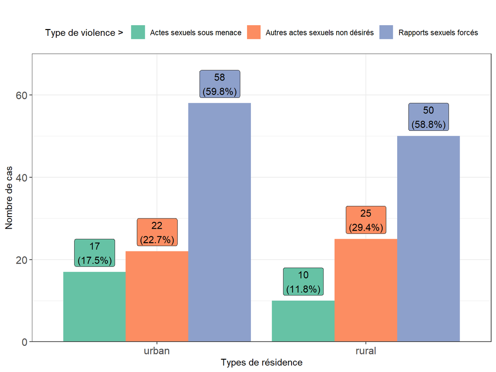

### 2.2.2 Distribution par groupe d’âge de la répondante

Le graphique ci-dessous illustre la **représentativité des femmes enquêtées** par tranche d’âge (barres bleues) ainsi que la **proportion de celles qui déclarent avoir subi une violence sexuelle** (barres noires).

On observe que la distribution des femmes interrogées est relativement équilibrée, avec une concentration notable entre **20 et 34 ans**, correspondant à la période de forte vie conjugale et reproductive. Parmi elles, les femmes âgées de **25 à 29 ans** constituent la proportion la plus élevée de victimes de violences sexuelles conjugales, suivies des **30–34 ans**.

La prévalence diminue progressivement après 35 ans, et reste faible chez les adolescentes de **15–19 ans**, ce qui peut s’expliquer par :

- Une plus faible probabilité d’être déjà en union,
- Une possible sous-déclaration liée à la sensibilité du sujet.

Ces résultats confirment que le **cœur de la vie conjugale (25–34 ans)** est une période particulièrement critique en matière d’exposition aux violences sexuelles.

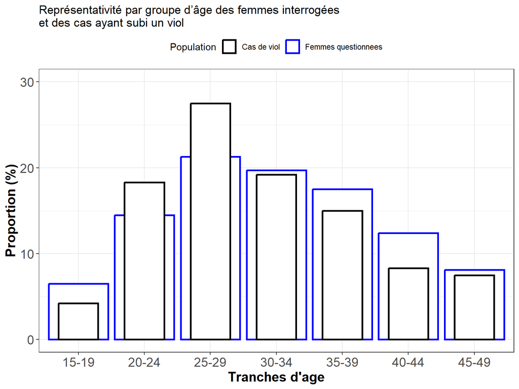

La répartition des types de violences sexuelles subies, au sein de chaque tranche d’âge, exprimée en proportions ressorte que :

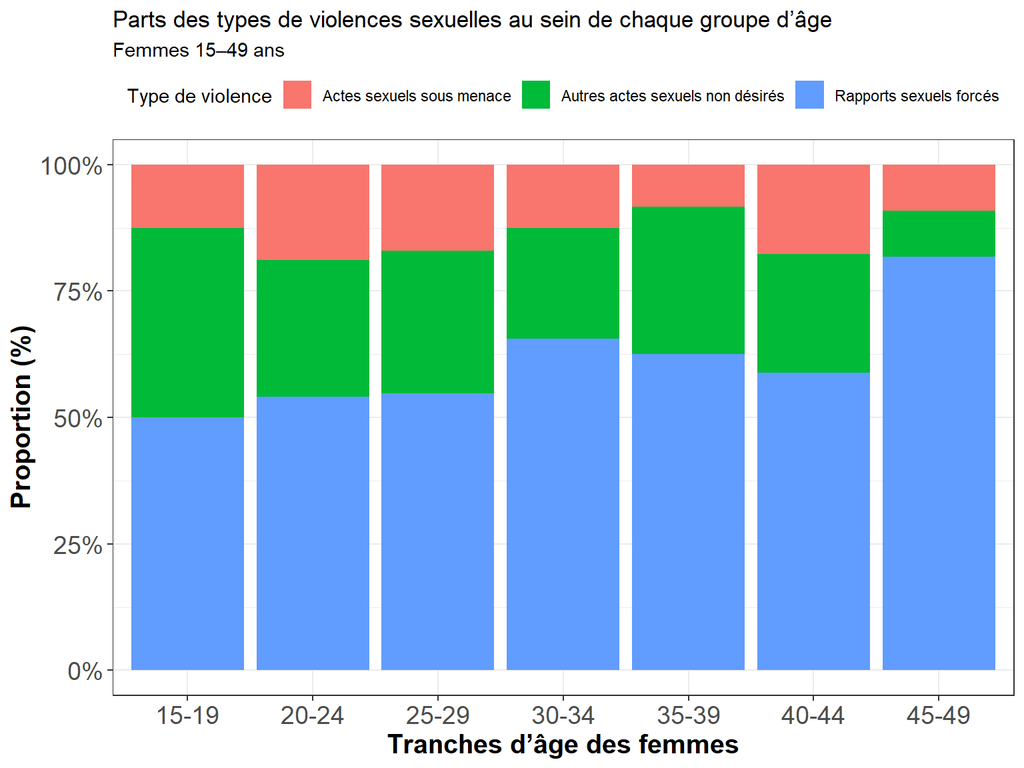

### 2.2.3 Niveau d’association

une forte concentration des cas de violences sexuelles conjugales parmi les couples où les deux partenaires n’ont aucun niveau d’instruction. Les flux les plus larges relient les femmes sans éducation à des partenaires également sans éducation, indiquant que cette combinaison constitue la situation la plus à risque.

Cependant, le graphique montre aussi que les femmes sans éducation demeurent particulièrement vulnérables même lorsqu’elles sont en union avec des hommes de différents niveaux d’étude (primaire, secondaire ou supérieur). Autrement dit, le faible niveau d’instruction des femmes semble être un facteur de vulnérabilité structurel, indépendamment de celui de leur partenaire.

Inversement, lorsque les femmes disposent d’un niveau d’instruction plus élevé (secondaire ou supérieur), la prévalence apparente des violences sexuelles est plus faible, quel que soit le niveau d’éducation de leur conjoint.

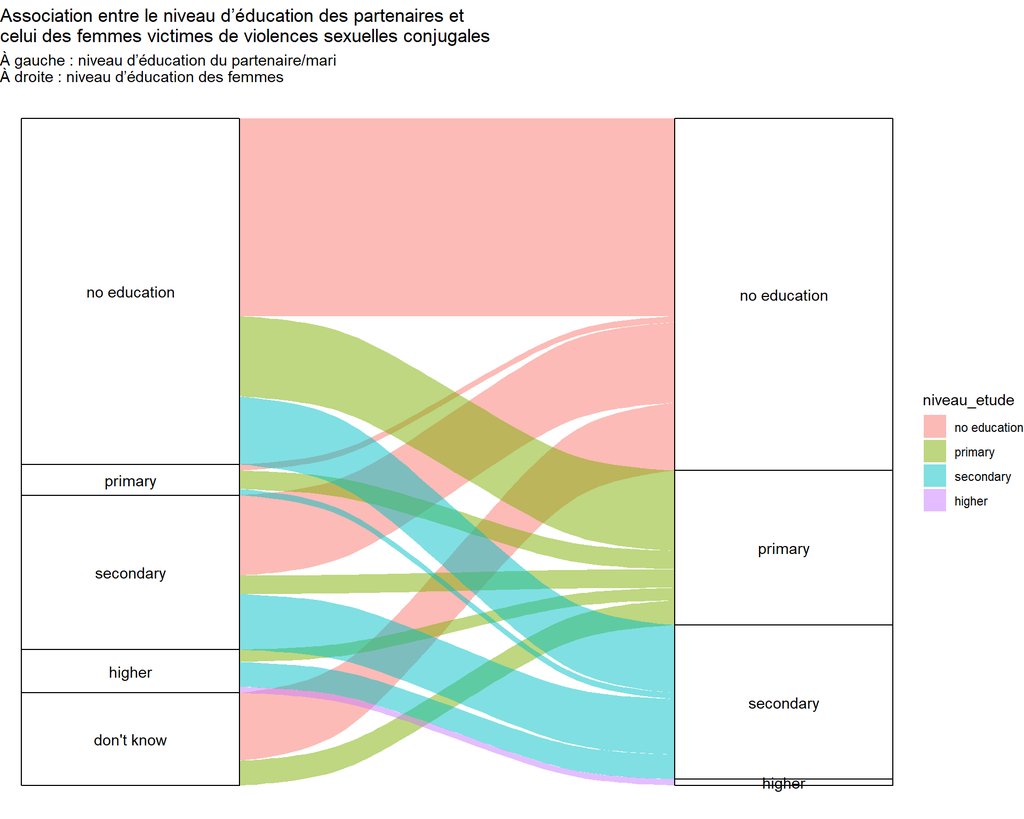

# 3 Conclusion

L’analyse des données de l’EDS de la Gambie met en évidence une prévalence relativement faible de la violence sexuelle perpétrée par un partenaire intime (6,1 %). Ce résultat peut traduire l’efficacité des politiques publiques de prévention, des campagnes de sensibilisation et une évolution des normes sociales vers une moindre tolérance de ces violences. Toutefois, il convient de rappeler que la sous-déclaration demeure fréquente sur ce type de sujet sensible, et que ces chiffres doivent être interprétés avec prudence. Les profils observés montrent que les femmes âgées de 25 à 34 ans, en pleine période conjugale et reproductive, sont les plus exposées, ce qui confirme que cette étape de la vie constitue un moment critique dans la dynamique des violences sexuelles.

Par ailleurs, l’étude souligne des disparités importantes liées au niveau d’instruction. Les couples où les deux partenaires n’ont aucun niveau d’éducation concentrent la majorité des cas, mais les femmes sans éducation restent vulnérables même lorsqu’elles vivent avec des partenaires plus instruits. Inversement, un niveau d’éducation plus élevé, chez l’un ou l’autre des partenaires, semble jouer un rôle protecteur. Ces résultats appellent à renforcer les interventions en matière d’éducation des filles et de sensibilisation des couples, tout en consolidant les dispositifs de protection et de soutien aux victimes. Ils rappellent également l’importance de poursuivre la lutte contre les inégalités de genre comme levier central pour prévenir les violences sexuelles conjugales.

# 4 Situation geographique du pays

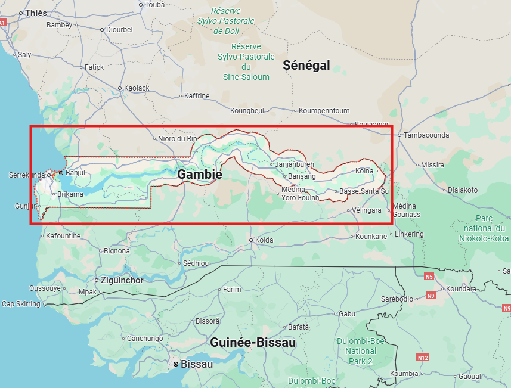

Cartographie de la Ghambie

La **Gambie** est le plus petit pays du continent africain continental, enclavé presque entièrement par le Sénégal, à l’exception d’une façade maritime étroite le long de l’océan Atlantique. Le pays s’étire de façon linéaire le long du fleuve Gambie sur environ 400 kilomètres, avec une largeur moyenne de seulement 50 kilomètres. Cette configuration géographique particulière confère au pays une identité fortement liée au fleuve, qui constitue à la fois l’axe de peuplement, de transport et de développement économique.

*La Gambie se situe en Afrique de l’Ouest*, dans une zone de climat tropical marqué par une saison sèche et une saison des pluies. La capitale, Banjul, est installée à l’embouchure du fleuve Gambie. Malgré sa petite superficie, le pays présente une diversité d’écosystèmes comprenant des zones côtières, des mangroves, des savanes et des plaines agricoles. Cette situation géographique stratégique, au carrefour de l’Afrique de l’Ouest et ouverte sur l’Atlantique, en fait un espace d’échanges, mais aussi un pays vulnérable aux pressions environnementales et économiques.